# MissionBio data quality Report

2022-07-07

### Intro

This report is aimed to obtain a global data quality overview for scDNA-seq samples from MissionBio. The quality metrics were computed by MissionBio Pipeline V2 and directly extracted from output H5 files.

Some metrics (e.g. “Mean reads/cell/amplicon” coverage) were not available in the H5 files, so they were calculated by reverse engineering the numbers that can be viewed on the MissionBio web portal.

The quality metrics of the Ghobrial lab samples were statistically compared with the quality metrics of the Bologna lab samples.

### Samples Cohort

The total dataset includes 22 samples:

- 6 samples from **Ghobrial lab**: 5 cell lines samples + 1 mixture sample (made with the other 5 cell lines)
- 16 samples from **Bologna lab**: 16 PB samples from 2 separate sequencing runs (8+8)

### All samples table overview

| sample | dataset | run | n_amplicons | n_cells | ado_rate | avg_panel_uniformity | mean_reads_cell_amplicon | chemistry_version | pipeline_version |
| --- | --- | --- | --- | --- | --- | --- | --- | --- | --- |
| scDNA_KMM1_reference | Ghobrial_lab | Ghob_run1 | 532 | 1779 | 0.1470 | 0.7631579 | 195 | V2 | 2.0.2 |
| scDNA_KMS11_reference | Ghobrial_lab | Ghob_run1 | 532 | 3184 | 0.0885 | 0.8139098 | 160 | V2 | 2.0.2 |
| scDNA_Mix_reference | Ghobrial_lab | Ghob_run1 | 532 | 2018 | 0.1800 | 0.7932331 | 193 | V2 | 2.0.2 |
| scDNA_MM1S_reference | Ghobrial_lab | Ghob_run1 | 532 | 3257 | 0.1360 | 0.7556391 | 91 | V2 | 2.0.2 |
| scDNA_OPM2_reference | Ghobrial_lab | Ghob_run1 | 532 | 2335 | 0.1140 | 0.7932331 | 154 | V2 | 2.0.2 |
| scDNA_RPMI8226_reference | Ghobrial_lab | Ghob_run1 | 532 | 1916 | 0.1330 | 0.7894737 | 193 | V2 | 2.0.2 |
| sample1 | Bologna_lab | Bolo_run1 | 127 | 2910 | 0.1740 | 0.9606299 | 33 | V2 | 2.0.2 |
| sample2 | Bologna_lab | Bolo_run1 | 127 | 3625 | 0.0840 | 0.9685039 | 45 | V2 | 2.0.2 |
| sample3 | Bologna_lab | Bolo_run1 | 127 | 3936 | 0.0910 | 0.9685039 | 27 | V2 | 2.0.2 |
| sample4 | Bologna_lab | Bolo_run1 | 127 | 1450 | 0.0920 | 0.9685039 | 136 | V2 | 2.0.2 |
| sample5 | Bologna_lab | Bolo_run1 | 127 | 904 | 0.0720 | 0.9685039 | 190 | V2 | 2.0.2 |
| sample6 | Bologna_lab | Bolo_run1 | 127 | 5980 | 0.0760 | 0.9685039 | 36 | V2 | 2.0.2 |
| sample7 | Bologna_lab | Bolo_run1 | 127 | 4972 | 0.0880 | 0.9685039 | 43 | V2 | 2.0.2 |
| sample8 | Bologna_lab | Bolo_run1 | 127 | 2949 | 0.1010 | 0.9527559 | 52 | V2 | 2.0.2 |
| Sample10 | Bologna_lab | Bolo_run2 | 127 | 1028 | 0.2235 | 0.9527559 | 57 | V2 | 2.0.1 |
| Sample11 | Bologna_lab | Bolo_run2 | 127 | 10684 | 0.2095 | 0.9606299 | 21 | V2 | 2.0.1 |
| Sample12 | Bologna_lab | Bolo_run2 | 127 | 4029 | 0.1540 | 0.9606299 | 38 | V2 | 2.0.1 |
| Sample13 | Bologna_lab | Bolo_run2 | 127 | 5510 | 0.0920 | 0.9685039 | 78 | V2 | 2.0.1 |
| Sample14 | Bologna_lab | Bolo_run2 | 127 | 13222 | 0.0440 | 0.9527559 | 26 | V2 | 2.0.1 |
| Sample15 | Bologna_lab | Bolo_run2 | 127 | 2889 | 0.1000 | 0.9685039 | 122 | V2 | 2.0.1 |
| Sample16 | Bologna_lab | Bolo_run2 | 127 | 8385 | 0.0700 | 0.9685039 | 44 | V2 | 2.0.1 |
| Sample17 | Bologna_lab | Bolo_run2 | 127 | 6231 | 0.0755 | 0.9685039 | 33 | V2 | 2.0.1 |

### Main metrics - comparisons between runs

#### Number of cells

Number of valid cells (number of cells called by the cellfinder module)

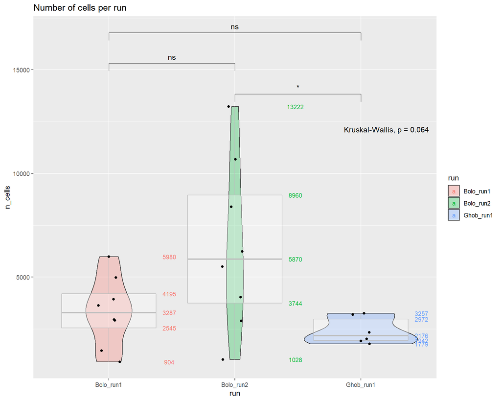

#### ADO rate

ADO (Allelic Dropout Rate) is the estimated rate of allelic dropout events. Calculated using germline variants (more informations [here](https://support.missionbio.com/hc/en-us/articles/360062390413-ADO-Calculation))

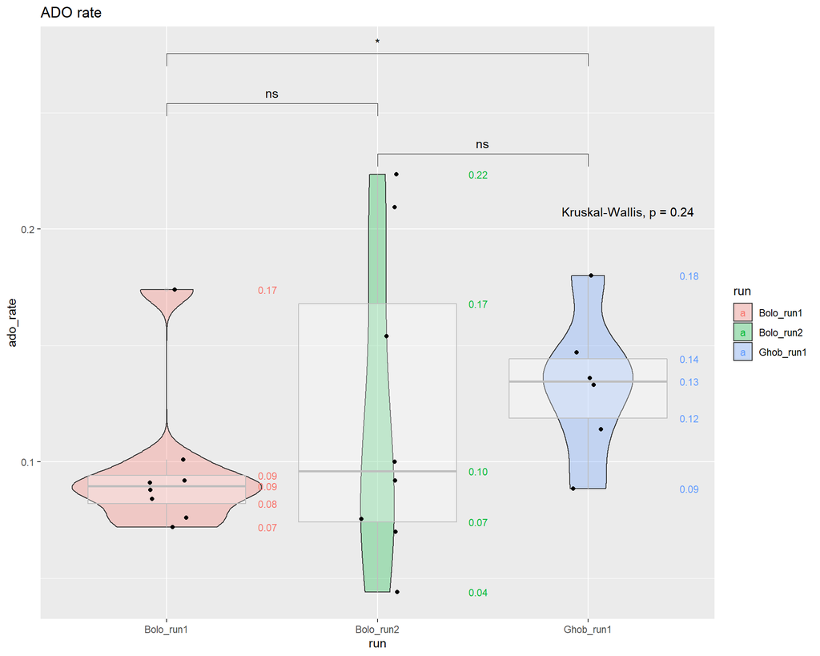

#### Average panel uniformity

This is the number of amplicons that have mean reads to the amplicon above 0.2 * the mean reads per amplicon per cell (ref. [here](https://support.missionbio.com/hc/en-us/articles/360053187154-Run-Report-Metrics#h_01EHSC7F4BZJ3678B16S0CTVVW)).

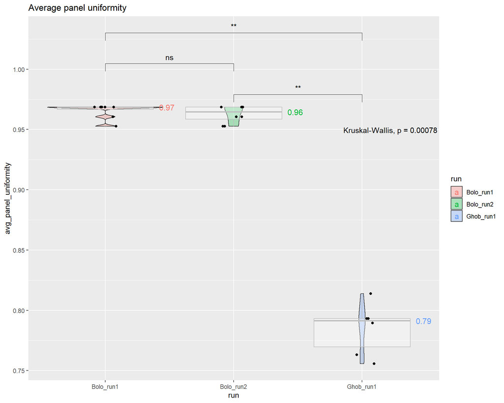

#### Mean reads/cell

This is the mean reads per called cell. It is the floor of the decimal obtained by dividing the total reads to cells by the number of cells.

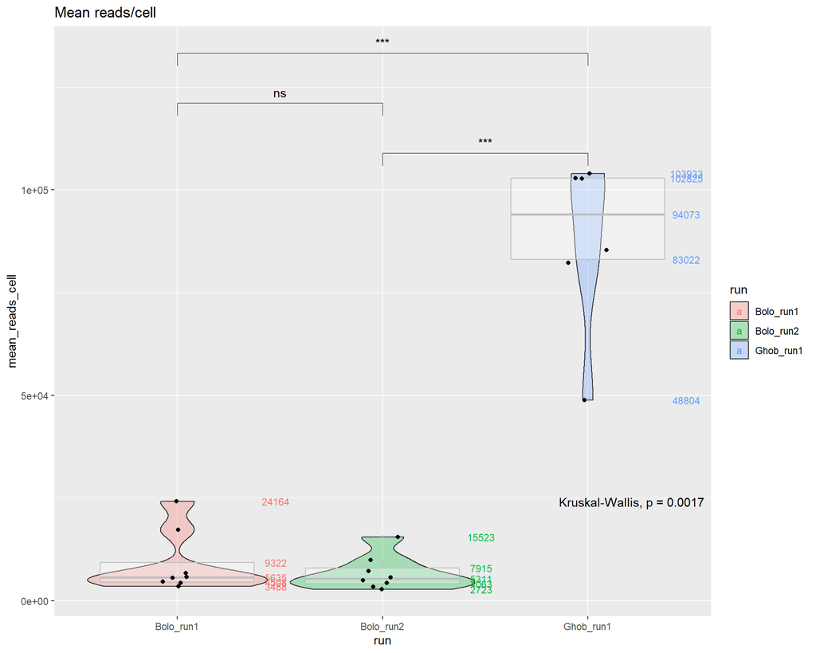

#### Mean reads/cell/amplicon

This is the floor of the mean reads per cell divided by the number of amplicons in the panel.

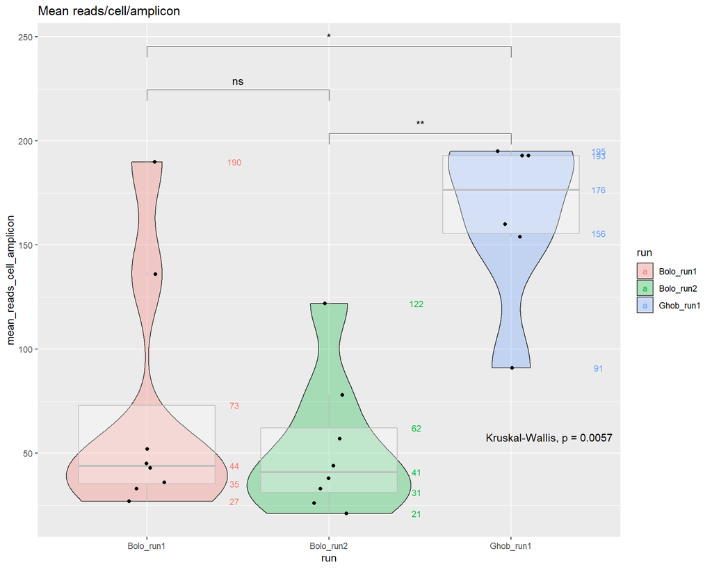

### Cutoffs chosen for mutation filtering

- **af_cutoff**: Minimum variant allelic fraction used for filtering variants.
- **dp_cutoff**: Minimum variant depth of coverage.
- **gq_cutoff:** minimum variant genotype quality.
- **missing_cells_cutoff:** variants that cannot be genotyped in more than this percentage of cells are not used.
- **mutated_cells_cutoff:** Variants that are not mutated in more than this percentage of cells are not used.
- **missing_variants_cutoff:** Cells that have more than this percentage of filtered variants that cannot be genotyped are not used.

  [reference link](https://missionbio.github.io/mosaic/4_data_structure.html#:~:text=and%20mutated_cells_cutoff.-,assay.dna.metadata,-Table)

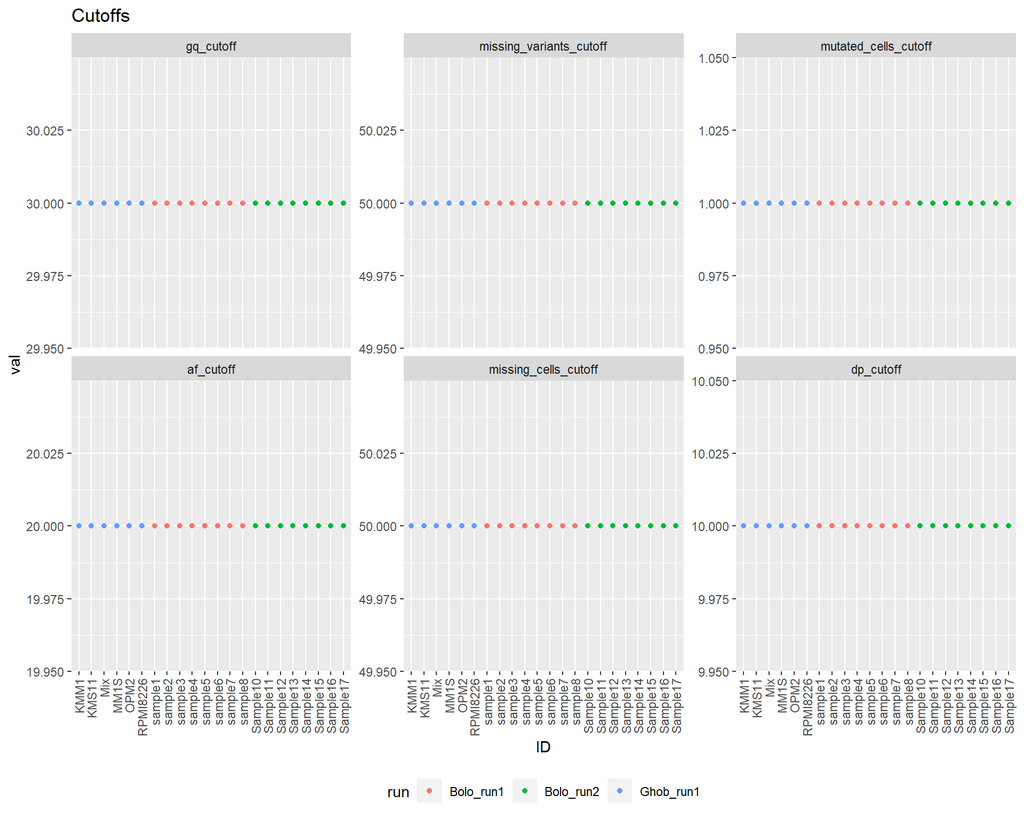

### Other stats

- **proportion_mappedToCell_total_read_pairs** = read pairs that mapped to the genome / total
- **proportion_validCell_total_read_pairs** = read pairs from cell barcodes that are valid / total
- **proportion_mappedInsert_total_reads** = reads that map to the amplicons / total
- **proportion_bases_r1_q30** = bases that have a Q value of 30 or greater from the forward reads / total
- **proportion_bases_r2_q30** = bases that have a Q value of 30 or greater from the reverse reads / total
- **proportion_bases_cellBarcode_q30** = bases (with quality of 30 or greater) from cell barcodes / total

  [reference link](https://missionbio.github.io/mosaic/4_data_structure.html?highlight=q30)

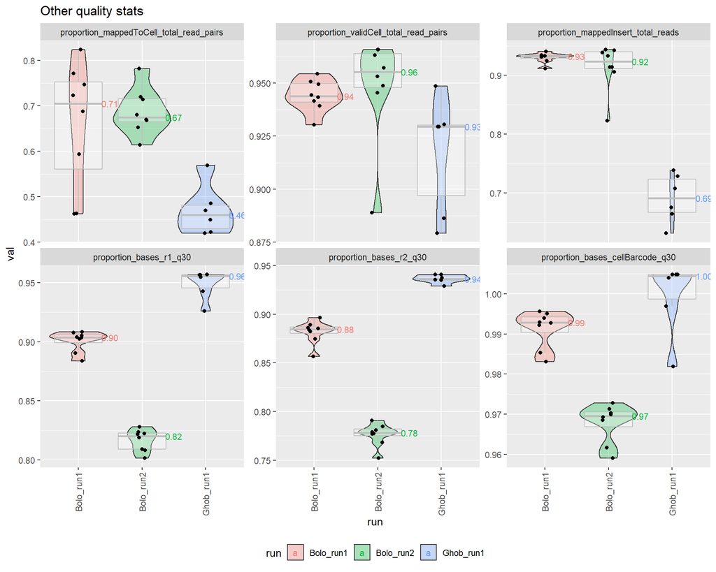